# R: Assigment 1

Takudzwa Machida 202002075

17/11/2020

# 1. BASICS

## 1.1. Variable in R

#### What is the value of " B " after running these command? [2]

```r
a <- 5.0
c <- 10
t <- 12
B <- a+c/t
```

- The value of B is 5.83

#### What type of vector do you get in each of the following? [4]

```r
vec_1 <- c(44, 5, 0, "k")
vec_2 <- c(1, 2, 3, FALSE)
vec_3 <- c("a", "b", "c", TRUE)
vec_4 <- c(1, 2, 3, "4")
```

- vec_1 we get a “character”
- vec_2 we get a “numeric”
- vec_3 we get a “character”
- vec_4 we get a “character”

## 1.2. Conditional subsetting

### Consider the following vector:

```r
vec <- c(141.2741, 141.8392, 140.5730,NA, 141.3571, 139.8689,
         137.9384, NA,139.6620, 138.2521, 138.8635, 141.3885, NA)
```

#### 1.2.1. Create a vector vec_1 with no missing values using conditional subsetting and explain your code [3]

```r
x <- is.na(vec)
vec_1<-vec[!x]
print(vec_1)
```

```
##  [1] 141.2741 141.8392 140.5730 141.3571 139.8689 137.9384 139.6620 138.2521
##  [9] 138.8635 141.3885
```

- Contents of the vector with no missing values: 141.2741, 141.8392, 140.573, 141.3571, 139.8689, 137.9384, 139.662, 138.2521, 138.8635, 141.3885

Explanation:

- the code “is.na(vec)” searches positions in the vector where there is NA and prints True and if NA is not there prints False.
- ‘!x’ are the positions in the vector where we dont have NA and vec[!x] print are the known values in the vector.
- ‘print(vec_1)’ displays the vector with no missing terms.

#### 1.2.2. Create a vector of indexes of missing values using conditional subsetting and explain your code [3]

```r
y<-vec[is.na(vec)]
print(y)
```

```
## [1] NA NA NA
```

Explanation:

- “is.na(vec)” are the positions where missing value (NA) are.
- “vec[is.na(vec)]” is assigned to y and if y is called the missing values NA are displayed.

#### 1.2.3. Write a code to determine how many missing values are in vec. [2]

```r
y<-length(vec[is.na(vec)])
print (y)
```

```
## [1] 3
```

- there are 3 missing values in the vector.

#### 1.2.4. Write a R code to create a data frame which contains details of 3 students as follows: [4]

```
Name,
Surname,
Age,
Gender.
```

```r
name <- c("Abiola","Mufaro","Paida")
surname <- c("Machida","Vandirai","Andonate")
Age <- c(23,25,20)
Gender <- c("Female","Male","Female")
df <- data.frame(name,surname,Age,Gender)
print(df)
```

```
##     name  surname Age Gender
## 1 Abiola  Machida  23 Female
## 2 Mufaro Vandirai  25   Male
## 3  Paida Andonate  20 Female
```

## 2. Functions in R

2.1. Create a function which returns a mean of an input vector and explain your code [4]

```r
The_Mean <- function(vector){
  z <- mean(vector,na.rm = TRUE)
  return(z)
}

trial_vector <- c(1,2,3,NA,5)
The_Mean(trial_vector)
```

```
## [1] 2.75
```

Explanation:

- “The_Mean” is the name to the function i have created which i will call when i want to calculate the mean of the input vector.
- l have also passed one parameter in the function which represece the input vector.
- the code " z <- mean(vector,na.rm = TRUE)" looks in the vector and if there are any missing values, the are ignored and the mean if calculated

#### 2.2. Create a function which take no inputs , it reads a Titanic .csv file and returns its content and explain your code. [3]

```r
library(tidyverse)
df<- function(){     #giving my function a name df
  x <- tibble(read.csv("train.csv")) # this line of code reads the csv file stored in computer named train and assigns to x
  return(x)   #after reading the csv file this line allows to output the information in the csv file
}
df()  #displays the info of the csv file
```

```
## # A tibble: 891 x 12
##    PassengerId Survived Pclass Name  Sex     Age SibSp Parch Ticket  Fare Cabin
##          <int>    <int>  <int> <chr> <chr> <dbl> <int> <int> <chr>  <dbl> <chr>
##  1           1        0      3 Brau~ male     22     1     0 A/5 2~  7.25 ""
##  2           2        1      1 Cumi~ fema~    38     1     0 PC 17~ 71.3  "C85"
##  3           3        1      3 Heik~ fema~    26     0     0 STON/~  7.92 ""
##  4           4        1      1 Futr~ fema~    35     1     0 113803 53.1  "C12~
##  5           5        0      3 Alle~ male     35     0     0 373450  8.05 ""
##  6           6        0      3 Mora~ male     NA     0     0 330877  8.46 ""
##  7           7        0      1 McCa~ male     54     0     0 17463  51.9  "E46"
##  8           8        0      3 Pals~ male      2     3     1 349909 21.1  ""
##  9           9        1      3 John~ fema~    27     0     2 347742 11.1  ""
## 10          10        1      2 Nass~ fema~    14     1     0 237736 30.1  ""
## # ... with 881 more rows, and 1 more variable: Embarked <chr>
```

## 3. Conditionals and Loops

#### 3.1. Write a function that take an input below and returns a transformed vector below into 1 when its element is male and 2 when its female using ifelse. [8]

```r
g <- c("MALE","FEMALE","FEMALE","MALE","FEMALE","MALE","MALE","FEMALE", "MALE","MALE","FEMALE","MALE","MALE",
"FEMALE","MALE","MALE","MALE")

Gender <- function(){
  y <- ifelse(g=="MALE",1,2)
  return(y)
}
Gender()
```

```
##  [1] 1 2 2 1 2 1 1 2 1 1 2 1 1 2 1 1 1
```

*The transfomed vector where 1 is Male and 2 is Female:

1, 2, 2, 1, 2, 1, 1, 2, 1, 1, 2, 1, 1, 2, 1, 1, 1

Eplanation:

- “Gender” is the name i have given to the function which uses the converts male to 1 and female to 2.
- The “ifelse” statement goes through vector ‘g’ and if element is MALE it returns 1 and if not it returns 2.

#### 3.2. Generate x from normal distribution and sample with replacement “M” and “F” for male and female respectively by running the code below.

```r
x <- rnorm(1000, 120, 5)
y <- sample(c("M","F"),size = 1000, replace = TRUE)
```

3.2.1. Use the “cbind” function in R to create one dataset and assign it to df. [2]

```r
x <- rnorm(1000, 120, 5)
y <- sample(c("M","F"),size = 1000, replace = TRUE)
df <- cbind(x,y)

print(head(df))  # the first 6 elements
```

```
##      x                  y
## [1,] "116.483255708189" "F"
## [2,] "120.844679466571" "M"
## [3,] "114.721911508309" "F"
## [4,] "124.381491680708" "F"
## [5,] "120.218727082549" "M"
## [6,] "120.851285581349" "F"
```

3.2.2. Convert df from 3.2.1 into a data.frame [2]

```r
x <- rnorm(1000, 120, 5)
y <- sample(c("M","F"),size = 1000, replace = TRUE)
#df from 3.2.1
df <- data.frame(df)

print(head(df))  # first 6
```

```
##                  x y
## 1 116.483255708189 F
## 2 120.844679466571 M
## 3 114.721911508309 F
## 4 124.381491680708 F
## 5 120.218727082549 M
## 6 120.851285581349 F
```

3.2.3. Write a code using tidyverse to compute a number of males (“M”) and females (“F”) in 3.2.1 [3]

```r
library(tidyverse)
df %>% group_by(y) %>% count()
```

```
## # A tibble: 2 x 2
## # Groups:   y [2]
##   y         n
##   <chr> <int>
## 1 F       492
## 2 M       508
```

3.2.4. Create a bar plot using ggplot to visualize your results in 3.2.3 [5]

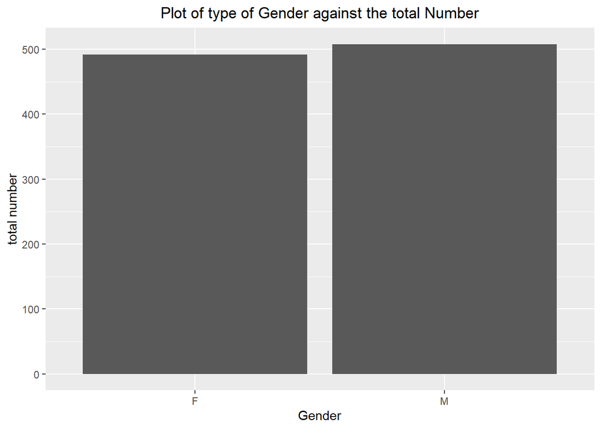

```r
library(ggplot2)
df %>% group_by(y) %>% count %>%
  ggplot(aes(x=y,y=n,))+
  geom_col()+
  labs(y="total number",x="Gender",title="Plot of type of Gender against the total Number")+
  theme(plot.title=element_text(hjust = 0.5))
```

3.2.5. Use mutate function to add sum of x per “M” and “F” and plot the results using sum of x per “M” and “F”. [5]

[figure not shown]

```r
df %>% group_by(y) %>% count() %>%
  mutate(new_col=sum(n)) %>%
  ggplot(aes(x=y,y=new_col))+
  geom_col()+
  labs(y="Sum per M and F",x="Gender",title="Plot of results using sum of x per M and F")+
  theme(plot.title=element_text(hjust = 0.5))
```